# GWSW Revisies

Stichting RIONED is initiatiefnemer en eigenaar van dit GitHub-project, Eric Oosterom is de verantwoordelijk projectmanager. De inhoud van GWSW Revisies is in grote mate tot stand gekomen in samenwerking met GWSW-Opera B.V., die samen met een partners GWSW-Inmeten een aantal Proof-of-Concepts (PoC’s) heeft uitgevoerd.

Vragen over deze website en het GWSW kunt u stellen via gwsw@rioned.org.

# Inleiding

Het inmeten van vaste gegevens is een activiteit die bijdraagt aan goed beheer van stedelijk watervoorzieningen. Door ontbrekende, foutieve of achterhaalde maatvoeringen (opnieuw) in te meten ontstaat een betrouwbaar beheerbestand waarmee kostbare besluiten onderbouwd kunnen worden, bijvoorbeeld als basis voor een hydrodynamisch rekenmodel dat wordt gebruikt om te bepalen of stelselaanpassingen nodig zijn. Een foutieve leidingdiameter of verouderde overstortdrempelhoogte in zettingsgevoelig gebied kan dan al snel leiden tot grote verschillen tussen theoretische modelberekeningen en wat buiten gebeurt tijdens hevige neerslag. De ligging van vaste gegevens op orde hebben is ook een belangrijk middel om graafschade door grondroerders te voorkomen.

Door te werken met GWSW-conforme datasets van opdrachtgever naar landmeter over in te meten objecten en daarna vice versa met meetresultaten terug, ontstaat een efficiënte informatie-uitwisseling waar op eenvoudige wijze validatieregels aan toe te voegen zijn die controleren op volledigheid en eventueel foutieve metingen.

Het initiatief voor dit deelmodel komt voor een belangrijk deel van de GWSW-Opera organisatie. De basis ligt bij een PoC gericht op het ontwikkelen en toetsen van het inmeetproces, dus de gegevensuitwisseling tussen landmeter en beheerder.

## Doel en toepassing

Ondersteuning bij revisies en andere metingen van stedelijk water voorzieningen, vooral het efficiënt en effectief verwerken van inmetingen door de landmeter.

**Revisie**  
De term “revisie” wordt gebruikt voor het inmeten van de objectgegevens na de aanleg (de realisatie van het ontwerp). Dit deelmodel heeft een bredere scope, ook het inmeten van al langer in gebruik zijnde objecten is een toepassing van dit deelmodel. Denk dan bijvoorbeeld aan het verbeteren van de bestaande registratie of het actualiseren van gegevens na verzakkingen.

## Leeswijzer

In hoofdstuk twee van dit ontwerpdocument wordt beschreven uit welke elementen een revisieproject bestaat en welke gegevens van de opdrachtgever (beheerder) naar de opdrachtnemer (landmeter) worden uitgewisseld en andersom. Hoofdstuk drie gaat over de uitwisselingsformaten (CSV, JSON, OroX) waarmee deze gegevens kunnen worden uitgewisseld. Tot slot beschrijft hoofdstuk vier de aanpassingen aan het GWSW datamodel.

# Projectmodel

Dit hoofdstuk beschrijft de opbouw van een revisieproject. Een revisieproject bestaat uit de algemene kenmerken van een project (opdrachtgever, opdrachtnemer, projectreferentie, etc.), waaraan verschillende deelactiviteiten, oftewel acties, aan gekoppeld zijn (zie ook Figuur 2.1).

**Deelactiviteiten**  
De deelactiviteiten van een revisieproject gaan over het inmeten van een knooppunt (put of bouwwerk) en/of het inmeten van een leiding. Een deelactiviteit heeft algemene kenmerken zoals meldingen, opmerkingen en de wijze van inwinning. Elke activiteit kent een in- en uitvoer, waarin de gegevens staan die richting de landmeter gaan en na meten weer terugkomen.

**Invoer**  
Een knooppunt of leiding met oorspronkelijke kenmerken zoals afmetingen vormt de invoer voor de deelactiviteit. Die gegevens komen uit het beheersysteem of vanuit het ontwerpplan en gaan naar de opdrachtnemer (landmeter) zodat bekend is welk object ingemeten dient te worden.

**Uitvoer**  
Het ingemeten object wordt als uitvoer van de deelactiviteit beschreven, de ingemeten kenmerken zoals afmetingen en hoogteligging worden - net zoals bij het invoer-object - bij het uitvoer-object opgenomen. Waargenomen toestandsgegevens (een soort meting) zoals “meting waterstand” worden als aparte uitvoer bij de deelactiviteit beschreven.

Hetzelfde fysieke object kan dus (met bijbehorende kenmerken) in twee vormen voorkomen: als invoer (definitie) en/of als uitvoer (resultaat) bij de activiteit. Volgens het GWSW Datamodel hebben die invoer- en uitvoer-vorm dezelfde objectnaam (rdfs:label) maar een eigen URI, daardoor hebben de bijbehorende kenmerken ook een invoer- en uitvoer-vorm.

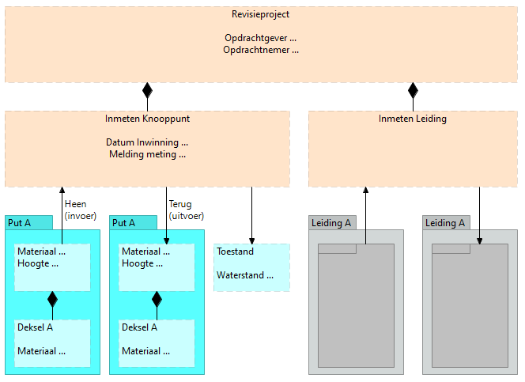

*Figuur 2.1 - Schematisatie revisieproject met de verschillende deelactiviteiten (acties)*

# Gegevensuitwisseling

Een revisieproject gebruikt de projectdefinitie en gegevens over de oorspronkelijke kenmerken van de in te meten objecten. Dit kunnen brongegevens zijn of gegevens afkomstig van de GWSW-server, zie ook Figuur 3.1. Als projectresultaat worden de inmetingen terug geleverd. Veelal wordt hierbij ook een verschilanalyse uitgevoerd en een rapportage opgeleverd. Uitwisseling van inmeetgegevens tussen de opdrachtgever en de opdrachtnemer geschiedt via een uitwisselingsformaat in OroX, JSON of CSV. Deze uitwisselingsformaten zijn in de onderstaande paragrafen uitgewerkt.

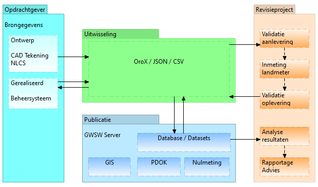

*Figuur 3.1 - Schematische weergave van de gegevensuitwisseling via Orox / JSON / CSV in verschillende stadia van een revisieproject*

## GWSW-OroX formaat

Beheersystemen kunnen veelal omgaan met een GWSW-datasets, ze exporteren of importeren dan een dataset (bestand) conform het GWSW-OroX protocol. Zo’n dataset is direct bruikbaar op het GWSW platform, waarmee de gegevens voor allerlei algemene toepassingen beschikbaar komen. Zo kan de inhoud direct in GIS systemen worden ontsloten. Zie ook https://apps.gwsw.nl.

Ook de gegevens van een revisieproject kunnen via het OroX-protocol worden uitgewisseld, dat is de meest directe vorm van uitwisseling. Het complete revisieproject, zowel de definitie als de resultaten past dan in één dataset. In de bijlage van dit ontwerpdocument is een voorbeeldbestand volgens het OroX-protocol opgenomen

**Validatie uitwisseling**  
Gebruik voor de validatie van de volledigheid van heen- en terug-gegevens ook de tabellen in de volgende paragraaf, zie de kolommen “Heen” en “Terug”

Het GWSW-OroX protocol is een speciaal formaat, ingericht op het uitwisselen via linked data en het kunnen bouwen van ontologiën. Een ontologie is een speciale datastructuur waarin de stedelijk water voorzieningen volledig beschreven kunnen worden, dat geldt voor zowel de systemen als de (beheer)processen.

## Tussenvorm CSV of JSON

Linked data formaten zoals het GWSW-OroX zijn vaak minder bekend bij uitvoerende partijen zoals de landmeter bij inmetingen of de CAD-tekenaar bij het ontwerp van systemen. Om die reden zijn er tussenvormen beschikbaar in bekendere formaten zoals CSV en JSON (minder bekend maar wel eenvoudig van opzet). Omzetters van CSV naar JSON en vice versa zijn algemeen beschikbaar.

Via CSV of JSON worden de gegevens uitgewisseld in aparte heen- en terug-bestanden (analoog aan de GWSW-RibX uitwisseling). Nadeel van deze route is dat er sprake is van enige redundantie, zo komen projectgegevens zowel in het heen- als terug bestand voor. Daarmee zijn deze tussenvormen foutgevoeliger.

In deze tussenvorm zijn er vier groepen: Project, Knooppunt, Deksel en Leiding. Elk uitwisselgegeven wordt geïdentificeerd door deze groep + de veldcode (zie hierna).

**CSV**

In het CSV-formaat is het heen- en terug-bestand een zipfile met daarin voor elke groep een apart CSV-bestand. De veldcodes uit de onderstaande tabellen per groep, vormen de kolomheader voor het CSV-bestand. Wanneer een kolom meerdere waarden bevat, bijvoorbeeld meerdere foto’s bij een put, worden deze gescheiden door middel van een ‘pipe’ teken ‘|’.

```
Bestandstype;Versie;Naam;Opdrachtgever;Opdrachtnemer;ProjectreferentieOpdrachtgever;ProjectreferentieOpdrachtnemer;Omschrijving;Contactpersoon;WijzeVanInwinningKnooppunt;WijzeVanInwinningDeksel;WijzeVanInwinningLeiding;Knooppuntnamen;WijzeVanInwinningXY;WijzeVanInwinningZ
"Revisie terug";"1.6.2";"Inmeten alles";"Gemeente Juinen";"Hekking Meetadvies B.V.";"OPD12345";"AAN67890";"Inmeting klein Juinen";"Walter de Rochebrune";"Inmeting";"GNSS Vanuit wagen";"Inmeting";"K9999"|"K9998"|"K9997"|"K9996"|"K9995"|"K9994"|"K9993"|"K9992";"GNSS Landmeting";"GNSS Landmeting"
```

**JSON**

In JSON-vorm is elke groep een object binnen het omvattende JSON-object, elk groep-object bevat vervolgens een object-array met daarin objecten met elementnamen conform de veldcode. In het JSON-formaat is een heen- en terug-bestand een tekstfile met daarin de JSON-string. In de bijlage is voor zowel het heen- als terugbestand een voorbeeld opgenomen.

In de volgende tabellen staan de uitwisselgegevens per groep, de veldcode identificeert dus het gegeven per groep.

**Vullingsvoorschriften uitwisseling (identiek aan de RibX-definitie):**

De vullingsvoorschriften staan in twee kolommen: * “Heen”: de veldvulling in een vooraf aangeleverd uitwisselbestand, afkomstig van (het beheersysteem van) de rioleringsbeheerder. * “Terug”: de veldvulling in een terug geleverd uitwisselbestand, de resultaten van de landmeter.

De kolommen “heen” en “terug” gebruiken de volgende codes om aan te geven of een gegeven verplicht is:

| Code | Voorschrift veldvulling in uitwisselbestand |
| --- | --- |
|  | Geen code in kolom “heen”: Niet vooraf invullen |
|  | Geen code in kolom “terug”: Niet achteraf invullen (terug zonder wijziging) |
| O | Optioneel |
| A | Altijd *) |

*) Als voor de kolom “heen” geldt dat het gegeven verplicht is (A) en het gegeven ontbreekt in het heen-bestand, dan moet de rioleringsbeheerder met de landmeter afspraken maken over de teruglevering. Wanneer het gegeven voor zowel “heen” als “terug” verplicht is (A) en het “heen”-gegeven is fout of ontbreekt (nieuw object, niet vooraf ingevuld), dan moet de landmeter dit gegeven – als het bekend is – altijd bij de inmeting corrigeren of aanvullen.

**Link naar datamodel GWSW**

Het GWSW-datamodel beschrijft de gebruikte concepten, de definitie en het waardetype is daarin beschreven.  
Elk concept linkt via een URI naar het GWSW-datamodel (de deelmodellen onder https:data.gwsw.nl/totaal of https:data.gwsw.nl/revisies).

**Gegevens Project**

| Veldcode | Omschrijving | Waardetype (in RDF-termen) | Heen | Terug | Opmerking |
| --- | --- | --- | --- | --- | --- |
| Naam | Naam project | rdfs:label bij Revisieproject | A |  |  |
| Opdrachtgever | Opdrachtgever | rdfs:label bij Opdrachtgever | A |  |  |
| Opdrachtnemer | Opdrachtnemer | rdfs:label bij Opdrachtnemer | A |  |  |
| ProjectreferentieOpdrachtgever | Projectreferentie Opdrachtgever | rdfs:label bij ProjectreferentieOpdrachtgever | A |  |  |
| ProjectreferentieOpdrachtnemer | Projectreferentie Opdrachtnemer | rdfs:label bij ProjectreferentieOpdrachtnemer | A |  |  |
| Omschrijving | Omschrijving project | rdfs:comment bij Revisieproject | A |  |  |
| Contactpersoon | Contactpersoon | rdfs:label bij Contactpersoon | A |  |  |
| WijzeVanInwinningKnooppunt | Wijze van inwinning Knooppunt | gwsw:hasReference WijzeVanInwinningColl |  | A |  |
| WijzeVanInwinningDeksel | Wijze van inwinning Deksel | gwsw:hasReference WijzeVanInwinningColl |  | A |  |
| WijzeVanInwinningLeiding | Wijze van inwinning Leiding | gwsw:hasReference WijzeVanInwinningColl |  | A |  |
| Knooppuntnamen | Beschikbare knooppuntnamen | rdfs:label | O |  |  |
| WijzeVanInwinningXY | Wijze van inwinning XY | gwsw:hasReference WijzeVanInwinningColl |  | A |  |
| WijzeVanInwinningZ | Wijze van inwinning X | gwsw:hasReference WijzeVanInwinningColl |  | A |  |

**Gegevens Knooppunt** (Put of Bouwwerk)

| Veldcode | Omschrijving | Waardetype (in RDF-termen) | Heen | Terug | Opmerking |
| --- | --- | --- | --- | --- | --- |
| Naam | Naam put of bouwwerk | rdfs:label bij Put of Bouwwerk | A | A |  |
| Type | Type put of bouwwerk | rdf:type Put of Bouwwerk | O | A |  |
| NaamStelsel | Naam stelsel | rdfs:label bij Stelsel | A | A |  |
| TypeStelsel | Type stelsel | rdf:type Stelsel | O | O |  |
| DatumInwinning | Datum inwinning | gwsw:hasValue DatumInwinning |  | A |  |
| Vorm | Vorm put of bouwwerk | gwsw:hasReference VormPutColl | O | A |  |
| Breedte | Breedte put of bouwwerk | gwsw:hasValue BreedtePut of BreedteBouwwerk | O | A |  |
| Lengte | Lengte put of bouwwerk | gwsw:hasValue LengtePut of LengteBouwwerk | O | A |  |
| Materiaal | Materiaal put of bouwwerk | gwsw:hasReference MateriaalPutColl | O | A |  |
| Bodemprofiel | Bodemprofiel | gwsw:hasReference BodemprofielColl | O | A | Vanaf GWSW 1.6.1 |
| X | X coördinaat | gwsw:hasValue Punt | A | A |  |
| Y | Y coördinaat | gwsw:hasValue Punt | A | A |  |
| Z | Z coördinaat | gwsw:hasValue Punt | O | O |  |
| Hoogte | Hoogte put of bouwwerk | gwsw:hasValue HoogtePut of HoogteBouwwerk | O | A |  |
| StatusFunctioneren | Status functioneren | gwsw:hasReference StatusFunctionerenColl | O | A |  |
| Constructieonderdeel | Bevat constructieonderdeel | rdf:type Constructieonderdeel | O | A | String array |
| Drempelniveau | Drempelniveau | gwsw:hasValue Drempelniveau | O | A | Decimal array |
| Drempelbreedte | Drempelbreedte | gwsw:hasValue Drempelbreedte | O | A | Integer array |
| HoogteStellaag | Hoogte stellaag | gwsw:hasValue HoogteStellaag | O | A |  |
| Waterstand | Meting waterstand | gwsw:hasValue MetingWaterstand |  | A |  |
| Fotoreferentie | Fotoreferentie | rdfs:seeAlso bij Put of Bouwwerk |  | O | String array |
| Melding | Melding meting knooppunt | gwsw:hasReference MeldingMetingKnooppuntColl |  | O | String array |
| Opmerking | Opmerking | gwsw:hasValue Opmerking |  | O |  |

**Gegevens Deksel**

| Veldcode | Omschrijving | Waardetype (in RDF-termen) | Heen | Terug | Opmerking |
| --- | --- | --- | --- | --- | --- |
| Naam | Naam put of bouwwerk | rdfs:label bij Put of Bouwwerk | A | A |  |
| DatumInwinning | Datum inwinning | gwsw:hasValue DatumInwinning |  | A |  |
| X | X coördinaat | gwsw:hasValue Punt | A | A |  |
| Y | Y coördinaat | gwsw:hasValue Punt | A | A |  |
| Z | Z coördinaat | gwsw:hasValue Punt | O | O |  |
| Type | Type deksel | rdf:type Afdekking | O | A |  |
| Vorm | Vorm deksel | gwsw:hasReference VormDekselColl | O | A |  |
| Lengte | Lengte deksel | gwsw:hasValue LengteDeksel | O | A |  |
| Breedte | Breedte deksel | gwsw:hasValue BreedteDeksel | O | A |  |
| Materiaal | Materiaal deksel | gwsw:hasReference MateriaalDekselColl | O | A |  |
| Melding | Melding meting deksel | gwsw:hasReference MeldingMetingDekselColl |  | O | String array |
| Opmerking | Opmerking | gwsw:hasValue Opmerking |  | O |  |
| Fotoreferentie | Fotoreferentie | rdfs:seeAlso bij Put of Bouwwerk |  | O | String array |

**Gegevens Leiding**

| Veldcode | Omschrijving | Waardetype (in RDF-termen) | Heen | Terug | Opmerking |
| --- | --- | --- | --- | --- | --- |
| Naam | Naam leiding | rdfs:label bij Leiding | A | A |  |
| Type | Type leiding | rdf:type Leiding | O | A |  |
| NaamStelsel | Naam stelsel | rdfs:label bij Stelsel | A | A |  |
| TypeStelsel | Type stelsel | rdf:type Stelsel | O | O |  |
| DatumInwinning | Datum inwinning | gwsw:hasValue DatumInwinning |  | A |  |
| NaamKnooppuntBegin | Naam knooppunt begin | rdfs:label bij Put of Bouwwerk | A | A |  |
| NaamKnooppuntEind | Naam knooppunt eind | rdfs:label bij Put of Bouwwerk | A | A |  |
| BobKnooppuntBegin | Bob bij knooppunt begin | gwsw:hasValue BobBeginpuntLeiding | O | A |  |
| BobKnooppuntEind | Bob bij knooppunt eind | gwsw:hasValue BobEindpuntLeiding | O | A |  |
| BbbKnooppuntBegin | Bbb bij knooppunt begin | gwsw:hasValue BbbBeginpuntLeiding |  | A |  |
| BbbKnooppuntEind | Bbb bij knooppunt eind | gwsw:hasValue BbbEindpuntLeiding |  | A |  |
| StatusFunctioneren | Status functioneren | gwsw:hasReference StatusFunctionerenColl | O | A |  |
| Vorm | Vorm leiding | gwsw:hasReference VormLeidingColl | O | A |  |
| Hoogte | Hoogte leiding | gwsw:hasValue HoogteLeiding | O | A |  |
| Breedte | Breedte leiding | gwsw:hasValue BreedteLeiding | O | A |  |
| Materiaal | Materiaal leiding | gwsw:hasReference MateriaalLeidingColl | O | A |  |
| Fotoreferentie | Fotoreferentie | rdfs:seeAlso bij Leiding |  | O | String array |
| Melding | Melding meting leiding | gwsw:hasReference MeldingMetingLeidingColl |  | O | String array |
| Opmerking | Opmerking | gwsw:hasValue Opmerking |  | O |  |

# Datamodel

## Nieuwe GWSW-concepten

Veel URI’s staan al in het GWSW datamodel, voor het deelmodel Revisies zijn ook een aantal nieuwe concepten uitgewerkt. In de eerdere hoofdstukken zijn enkele van deze concepten al voorbijgekomen.

Een overzicht van de nieuw toegevoegde concepten (vanaf concept-deelmodel GWSW-Revisies 1.6.1):

[output not shown]

## Datamodel Revisies in RDF

Hieronder staat het eerste concept model met daarin alleen de toegevoegde revisie-concepten (in de uitgewerkte versies wordt de prefix rev: vervangen door gwsw: ).

De uitwerking van het complete deelmodel GWSW-Revisies staat onder https://data.gwsw.nl/Revisies.

Datamodel: Revisieproject

```
rev:Revisieproject rdf:type owl:Class ;
  rdfs:subClassOf gwsw:Project ;
  rdfs:label "Revisieproject";
  skos:definition "Revisieproject" ;
  rdfs:subClassOf \[ \# Kardinaliteits-restricie op activiteit InmetenKnooppunt (min=0)
    rdf:type owl:Restriction ;
    owl:onClass rev:InmetenKnooppunt ;
    owl:onProperty gwsw:hasPart ;
    owl:minQualifiedCardinality "0"^^xsd:nonNegativeInteger ;
  ] ;
  rdfs:subClassOf \[ \# Kardinaliteits-restricie op activiteit InmetenLeiding (min=0)
    rdf:type owl:Restriction ;
    owl:onClass rev:InmetenLeiding ;
    owl:onProperty gwsw:hasPart ;
    owl:minQualifiedCardinality "0"^^xsd:nonNegativeInteger ;
  ] ;
  skos:scopeNote rev:Cof_REV; \# Nieuw concept in deelmodel GWSW-Revisies
.
rev:InmetenKnooppunt rdf:type owl:Class ;
  rdfs:subClassOf gwsw:Meten ;
  rdfs:label "Inmeten knooppunt" ;
  skos:definition "Landmeetkundige inmeting van een put of bouwwerk" ;
  rdfs:subClassOf \[ \# Kardinaliteits-restricie op activiteit Revisieproject (exact=1)
    rdf:type owl:Restriction ;
    owl:onClass rev:Revisieproject ;
    owl:onProperty gwsw:isPartOf ;
    owl:qualifiedCardinality "1"^^xsd:nonNegativeInteger ;
  ] ;
  rdfs:subClassOf \[ \# Kardinaliteits-restricie op kenmerk WijzeVanInwinning (exact=1)
    rdf:type owl:Restriction ;
    owl:onClass gwsw:WijzeVanInwinning ;
    owl:onProperty gwsw:hasAspect ;
    owl:qualifiedCardinality "1"^^xsd:nonNegativeInteger ;
  ] ;
  rdfs:subClassOf \[ \# Kardinaliteits-restricie op kenmerk DatumInwinning (exact=1)
    rdf:type owl:Restriction;
    owl:onClass gwsw:DatumInwinning;
    owl:onProperty gwsw:hasAspect;
    owl:qualifiedCardinality "1"^^xsd:nonNegativeInteger ;
  ] ;
```

[output cut: 149 more lines]

```
  ] ;
  skos:scopeNote rev:Cof_REV; \# Nieuw concept in deelmodel GWSW-Revisies
.
rev:BbbEindpuntLeiding rdf:type owl:Class ;
  rdfs:subClassOf gwsw:Kenmerk ;
  rdfs:label "B.b.b. eindpunt leiding" ;
  skos:definition "Niveau binnenbovenkant buis ter plaatse van het eindpunt" ;
  rdfs:subClassOf \[ \# Kardinaliteits-restricie op topologisch element EinduntLeiding (exact=1)
    rdf:type owl:Restriction ;
    owl:onClass gwsw:EindpuntLeiding ;
    owl:onProperty gwsw:isAspectOf ;
    owl:qualifiedCardinality "1"^^xsd:nonNegativeInteger ;
  ] ;
  skos:scopeNote rev:Cof_REV; \# Nieuw concept in deelmodel GWSW-Revisies
.
```

## Projectmodel revisies in RDF (dataset)

Als we de meetgegevens combineren met het eerder beschreven projectmodel kan een GWSW-dataset worden opgebouwd. Zo’n GWSW-dataset omvat de complete uitwisseling binnen het revisieproject, dus zowel de gegevens van de heen- als van de terug-levering.

Het ziet er dan als volgt uit (in één GWSW-dataset):

Dataset: Voorbeeld revisieproject

```
\# ex: - prefix met de individuen, de objecten in de projectdefintie en in het terrein
\# gwsw: - bestaande gwsw-concepten
\# rev: - concepten in deelmodel GWSW-Revisies
\# rdf: / rdfs: - generieke RDF-concepten

{ex:01} \# Revisieproject
  rdfs:label "Inmeetproject Hollandse buurt";
  rdf:type rev:Revisieproject ;
  gwsw:isOutputOf \[ rdf:type gwsw:Opdrachtgever ; rdfs:label "Gemeente Juinen" ; ] ;
  gwsw:hasAspect \[ rdf:type rev:ProjectreferentieOpdrachtnemer ; rdfs:label "Pr20250101_00892" ; ] ;
  gwsw:isOutputOf \[ rdf:type gwsw:Contactpersoon ; rdfs:label "Walter de Rochebrune" ; ] ;
  rdfs:comment "Dit is een inmeetproject" ;
.
{ex:10} \# Inmeten knooppunt - activiteit
  gwsw:isPartOf {ex:01} ;
  rdf:type rev:InmetenKnooppunt ;
.
{ex:10} \# Inmeten knooppunt - projectdefinitie (heen)
  gwsw:hasInput {ex:11i} ;
.
{ex:10} \# Inmeten knooppunt - resultaat (terug)
  gwsw:hasOutput {ex:11o} ; \# Gebruik een andere URI dan ex:11i, ook bij hetzelfde knooppunt (houdt dezelfde naam)
  gwsw:hasAspect \[ rdf:type gwsw:WijzeVanInwinning ; gwsw:hasReference gwsw:Inmeting; ] ;
  gwsw:hasAspect \[ rdf:type gwsw:DatumInwinning ; gwsw:hasValue "20240828"^^xsd:date. ; ] ;
  rdfs:seeAlso _:24084\G265_1.jpg, _:24084\G265_2.jpg;
  gwsw:hasAspect \[ rdf:type rev:MeldingMetingKnooppunt ; rev:hasReference rev:GeurWaargenomen ; ] ;
  gwsw:hasAspect \[ rdf:type rev:MeldingMetingDeksel ; rev:hasReference rev:DekselGebroken ; ] ;
  gwsw:hasAspect \[ rdf:type gwsw:Opmerking ; gwsw:hasValue "Mooi weer buiten" ; ] ;
.
{ex:11i/ex:11o} \# Knooppunt heen en terug
  rdf:type  gwsw:ExterneOverstortput; /# Ga hier uit van supertype gwsw:Put
  rdfs:label "KN90001" ;
  gwsw:hasAspect \[ rdf:type gwsw:VormPut ; gwsw:hasReference gwsw:Rechthoekig ; ] ;
  gwsw:hasAspect \[ rdf:type gwsw:BreedtePut ; gwsw:hasValue 800 ; ] ;
  gwsw:hasAspect \[ rdf:type gwsw:LengtePut ; gwsw:hasValue 800 ; ] ;
  gwsw:hasAspect \[ rdf:type gwsw:MateriaalPut ; gwsw:hasReference gwsw:Beton ; ] ;
  gwsw:hasPart \[ rdf:type gwsw:Stroomprofiel; gwsw:hasAspect \[ rdf:type gwsw:VormStroomprofiel ; gwsw:hasReference gwsw:Geulprofiel ; ] ; ] ;
  gwsw:hasPart \[ rdf:type gwsw:Stellaag; gwsw:hasAspect \[ rdf:type gwsw:HoogteStellaag ; gwsw:hasValue 45 ; ] ; ] ;
  gwsw:hasAspect \[ rdf:type gwsw:HoogtePut ; gwsw:hasValue 2140 ; ] ;
  gwsw:hasAspect \[ rdf:type gwsw:StatusFunctioneren ; gwsw:hasReference gwsw:InGebruik ; ] ;
```

[output cut: 56 more lines]

```
  rdf:type gwsw:BeginpuntLeiding ;
  gwsw:hasConnection {ex:12} ; \# Afleiden uit {Leiding.KnooppuntBegin}
  gwsw:hasAspect \[ rdf:type gwsw:BobBeginpuntLeiding ; gwsw:hasValue 22.45 ; ] ;
.
{ex:24} \# Leiding heen en terug: eindpunt
  rdf:type gwsw:EindpuntLeiding ;
  gwsw:hasConnection {ex:12} ; \# Afleiden uit {Leiding.KnooppuntEind} {ex:12} is natuurlijk een andere put
  gwsw:hasAspect \[ rdf:type gwsw:BobEindpuntLeiding ; gwsw:hasValue 22.46 ; ] ;
.
{ex:241} \# Beginpunt terug
  gwsw:hasAspect \[ rdf:type rev:BbbBeginpuntLeiding ; gwsw:hasValue 22.75} ; ] ;
.
{ex:24o} \# Eindpunt terug
  gwsw:hasAspect \[ rdf:type rev:BbbEindpuntLeiding ; gwsw:hasValue 22.76 ; ] ;
.
```

# Bijlagen

## OroX Uitwisselbestand

**Voorbeeld bestand volgens het OroX-protocol**

```
@prefix rdf: <http://www.w3.org/1999/02/22-rdf-syntax-ns#>.
@prefix rdfs: <http://www.w3.org/2000/01/rdf-schema#>.
@prefix owl: <http://www.w3.org/2002/07/owl#>.
@prefix skos: <http://www.w3.org/2004/02/skos/core#>.
@prefix xsd: <http://www.w3.org/2001/XMLSchema#>.
@prefix geo: <http://www.opengis.net/ont/geosparql#>.
@prefix gwsw: <http://data.gwsw.nl/1.6/totaal/>.
@prefix ex: <http://sparql.gwsw.nl/instances#>.
ex:Proj_1 rdfs:label "Inmeten alles";
    rdfs:comment "Inmeting klein Juinen";
    a gwsw:Revisieproject;
    gwsw:hasInput [rdfs:label "Gemeente Juinen";
        a gwsw:Opdrachtgever],
        [rdfs:label "Hekking Meetadvies B.V.";
            a gwsw:Opdrachtnemer],
        [rdfs:label "Walter de Rochebrune";
            a gwsw:Contactpersoon];
    gwsw:hasAspect [ a gwsw:ProjectreferentieOpdrachtgever;
        gwsw:hasValue "OPD12345" ],
        [ a gwsw:ProjectreferentieOpdrachtnemer;
        gwsw:hasValue "AAN67890" ].
ex:Knp_2 rdfs:label "K0001";
    a gwsw:Inspectieput;
    gwsw:hasAspect [a gwsw:Putorientatie;
        gwsw:hasAspect [ a gwsw:Punt;
            gwsw:hasValue "163042.58 383220.11 undefined"^^geo:gmlLiteral ] ],
        [a gwsw:BreedtePut;
            gwsw:hasValue "800"^^xsd:integer],
        [a gwsw:LengtePut;
            gwsw:hasValue "800"^^xsd:integer],
        [a gwsw:VormPut;
            gwsw:hasReference gwsw:Rechthoekig],
        [a gwsw:MateriaalPut;
            gwsw:hasReference gwsw:Beton];
    gwsw:isPartOf ex:Stl_5;
    gwsw:hasPart [a gwsw:Stellaag].
ex:InmKnp_4 a gwsw:InmetenKnooppunt;
    gwsw:isPartOf ex:Proj_1;
    gwsw:hasInput ex:Knp_2;
    gwsw:hasAspect [ a gwsw:DatumInwinning;
```

[output cut: 250 more lines]

```
            gwsw:hasReference gwsw:Inmeting],
        [a gwsw:DatumInwinning;
            gwsw:hasValue "2026-06-15"^^xsd:date] ];
    gwsw:hasValue "16.12"^^xsd:decimal.
_:b1000_102 a gwsw:BbbBeginpuntLeiding;
    gwsw:hasValue "16.42"^^xsd:decimal.
_:b1000_103 a gwsw:BobEindpuntLeiding;
    gwsw:hasAspect [a gwsw:Inwinning;
        gwsw:hasAspect [a gwsw:WijzeVanInwinning;
            gwsw:hasReference gwsw:Inmeting],
        [a gwsw:DatumInwinning;
            gwsw:hasValue "2026-06-15"^^xsd:date] ];
    gwsw:hasValue "16.27"^^xsd:decimal.
_:b1000_106 a gwsw:BbbEindpuntLeiding;
    gwsw:hasValue "16.57"^^xsd:decimal.
```

## JSON Uitwisselbestand

**Voorbeeld bestand heen.json**

```
{
  "Project": [
    {
      "Bestandstype": "Revisie heen",
      "Versie": "0.1",
      "Naam": "Inmeten alles",
      "Opdrachtgever": "Gemeente Juinen",
      "Opdrachtnemer": "Hekking Meetadvies B.V.",
      "ProjectreferentieOpdrachtgever": "OPD12345",
      "ProjectreferentieOpdrachtnemer": "AAN67890",
      "Omschrijving": "Inmeting klein Juinen",
      "Contactpersoon": "Walter de Rochebrune"
    }
  ],
  "Deksel": [
    {
      "Naam": "K0001",
      "X": 163042.580,
      "Y": 383220.110,
      "Z": 15.28
    },
    {
      "Naam": "K0002",
      "X": 163035.930,
      "Y": 383176.510,
      "Z": 15.30
    }
  ],
  "Knooppunt": [
    {
      "Naam": "K0001",
      "X": 163042.580,
      "Y": 383220.110,
      "Type": "Inspectieput",
      "NaamStelsel": "Centrum hoofd",
      "TypeStelsel": "Gemengd stelsel",
      "Vorm": "Rechthoekig",
      "Breedte": 800,
      "Lengte": 800,
      "Materiaal": "Beton"
```

[output cut: 14 more lines]

```
      "Naam": "001",
      "Type": "Rioolleiding",
      "NaamStelsel": "Centrum hoofd",
      "TypeStelsel": "Gemengd stelsel",
      "NaamKnooppuntBegin": "K0001",
      "NaamKnooppuntEind": "K0002",
      "BobKnooppuntBegin": 16.43,
      "BobKnooppuntEind": 16.56,
      "Vorm": "Rond",
      "Hoogte": 300,
      "Breedte": 300,
      "Materiaal": "Beton"
    }
  ]
}
```

**Voorbeeld bestand terug.json**

```
{
  "Project": [
    {
      "Bestandstype": "Revisie terug",
      "Versie": "0.1",
      "Naam": "Inmeten alles",
      "Opdrachtgever": "Gemeente Juinen",
      "Opdrachtnemer": "Hekking Meetadvies B.V.",
      "ProjectreferentieOpdrachtgever": "OPD12345",
      "ProjectreferentieOpdrachtnemer": "AAN67890",
      "Omschrijving": "Inmeting klein Juinen",
      "Contactpersoon": "Walter de Rochebrune",
      "WijzeVanInwinningKnooppunt": "Inmeting",
      "WijzeVanInwinningDeksel": "GNSS Vanuit wagen",
      "WijzeVanInwinningLeiding": "Inmeting",
      "WijzeVanInwinningXY":"GNSS Landmeting",
      "WijzeVanInwinningZ": "GNSS Landmeting"
    }
  ],
  "Deksel": [
    {
      "Naam": "K0001",
      "DatumInwinning": "2026-01-01",
      "X": 163042.420,
      "Y": 383220.109,
      "Z": 15.30,
      "Type": "Deksel",
      "Vorm": "Rond",
      "Lengte": 520,
      "Breedte": 520,
      "Materiaal": "Gietijzer",
      "Melding": [ "Deksel gebroken", "Deksel boven maaiveld" ]
    },
    {
      "Naam": "K0002",
      "DatumInwinning": "2026-01-01",
      "X": 163035.890,
      "Y": 383176.600,
      "Z": 15.31,
      "Type": "Putdeksel - zwaar verkeer",
```

[output cut: 65 more lines]

```
      "BobKnooppuntBegin": 16.12,
      "BobKnooppuntEind": 16.27,
      "BbbKnooppuntBegin": 16.42,
      "BbbKnooppuntEind": 16.57,
      "StatusFunctioneren": "In gebruik",
      "Vorm": "Rond",
      "Hoogte": 300,
      "Breedte": 300,
      "Materiaal": "Beton",
      "Fotoreferentie": [ "Foto004.jpg", "Foto005.jpg" ],
      "Melding": [ "Grond in object","Object toegevoegd","Ongedierte in object" ],
      "Opmerking": "Dit is een opmerking"
    }
  ]
}
```